# Chicago’s Gun Violence Epidemic

Ben Dodson

11/8/2019

```r
#Setup the environment
knitr::opts_chunk$set(message = FALSE,
                      warning=FALSE, fig.align="center", cache=TRUE)
options(scipen=99)
library(tidyverse)
library(sf)
library(QuantPsyc)
library(RSocrata)
library(viridis)
library(caret)
library(spatstat)
library(spdep)
library(FNN)
library(grid)
library(gridExtra)
library(knitr)
library(kableExtra)
library(tidycensus)
library(ggplot2)

setwd("~/MUSA507/A09")

#Set a map theme
mapTheme <- function(base_size = 12) {
  theme(
    text = element_text( color = "black"),
    plot.title = element_text(size = 14,colour = "black"),
    plot.subtitle=element_text(face="italic"),
    plot.caption=element_text(hjust=0),
    axis.ticks = element_blank(),
    panel.background = element_blank(),axis.title = element_blank(),
    axis.text = element_blank(),
    axis.title.x = element_blank(),
    axis.title.y = element_blank(),
    panel.grid.minor = element_blank(),
    panel.border = element_rect(colour = "black", fill=NA, size=2)
  )
}

#Establish law enforcement areas
policeDistricts <-
  st_read("https://data.cityofchicago.org/api/geospatial/fthy-xz3r?method=export&format=GeoJSON") %>%
  st_transform(crs=102271) %>%
  dplyr::select(District = dist_num)

policeBeats <-
  st_read("https://data.cityofchicago.org/api/geospatial/aerh-rz74?method=export&format=GeoJSON") %>%
  st_transform(crs=102271) %>%
  dplyr::select(District = beat_num)

bothPoliceUnits <- rbind(mutate(policeDistricts, Legend = "Police Districts"),
                         mutate(policeBeats, Legend = "Police Beats"))

#Create the fishnet
chicagoBoundary <-
  st_read("chicagoBoundary.shp") %>%
  st_transform(crs=102271)

fishnet <-
  st_make_grid(chicagoBoundary, cellsize = 500) %>%
  st_sf()

fishnet <-
  fishnet[chicagoBoundary,] %>%
  mutate(uniqueID = rownames(.)) %>%
  dplyr::select(uniqueID)
```

## Chicago’s Gun Violence Problem

In 2017, Chicago had almost 3,000 reported assaults in which a handgun was involved. These incidents are present throughout the city, but are concentrated in certain areas - mainly those west and southwest of the loop. These crimes often go unreported out of fear of retaliation by the criminals and drawing in an increased police presence. Many gun-shot victims are dropped off at emergency rooms around the city which don’t provide an accurate picture of where these incidents are hapening on a neighborhood level. Localizing this problem, and predicting where these incidents are happening can equip law enforcement and community leaders with the intellengence to make decisions to prevent these assaults.

## Visualizing the Problem

```r
#Load the gun violence data
gunviolence <-
  read.socrata("https://data.cityofchicago.org/Public-Safety/Crimes-2017/d62x-nvdr") %>%
  filter(Primary.Type == "ASSAULT" &
           Description == "AGGRAVATED: HANDGUN") %>%
  mutate(x = gsub("[()]", "", Location)) %>%
  separate(x,into= c("Y","X"), sep=",") %>%
  mutate(X = as.numeric(X),
         Y = as.numeric(Y)) %>%
  na.omit %>%
  st_as_sf(coords = c("X", "Y"), crs = 4326, agr = "constant")%>%
  st_transform(102271) %>%
  distinct()
```

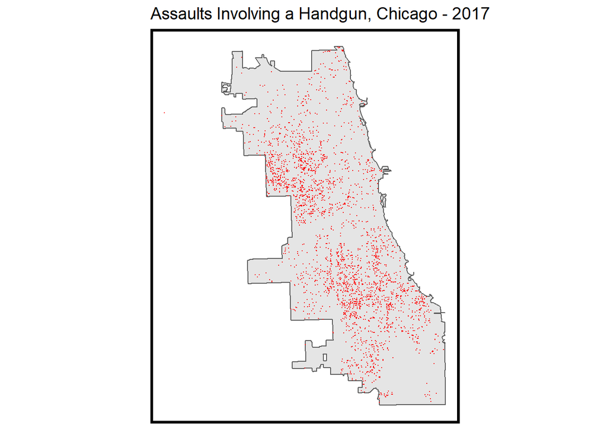

```r
#Plot assaults involving a handgun
ggplot() +
  geom_sf(data = chicagoBoundary) +
  geom_sf(data = gunviolence, colour="red", size=0.1, show.legend = "point") +
  labs(title= "Assaults Involving a Handgun, Chicago - 2017") +
  mapTheme()
```

This simple plot shows the dispersion of these instances but does not do an accurate job of identifying hotspots. (1)

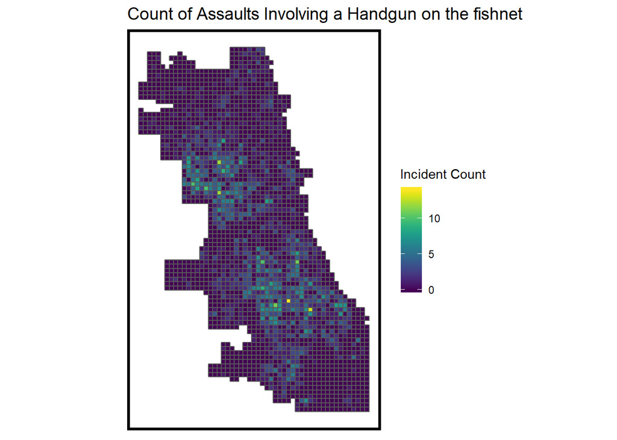

```r
#Append instances of gun violence to the fishnet geography
crime_net <-
  gunviolence %>%
  dplyr::select() %>%
  mutate(countgunviolence = 1) %>%
  aggregate(., fishnet, sum) %>%
  mutate(countgunviolence = ifelse(is.na(countgunviolence), 0, countgunviolence),
         uniqueID = rownames(.),
         cvID = sample(round(nrow(fishnet) / 24), size=nrow(fishnet), replace = TRUE))

#Plot gun violence on the fishnet
ggplot() +
  geom_sf(data = crime_net, aes(fill = countgunviolence)) +
  scale_fill_viridis(name="Incident Count") +
  labs(title = "Count of Assaults Involving a Handgun on the fishnet") +
  mapTheme()
```

Plotting instances of gun violence on the fishnet makes the concentration in the West and South sides of Chicago easier to identify. Both maps should be used to show that the problem is widespread but also more promiment in hotspots. (2)

## Understanding the Predictive Factors

By bringing in data using the OpenDataChicago civic data portal, local intelligence can provide indicators of this type of crime. The first step is to examine each risk factor individually.

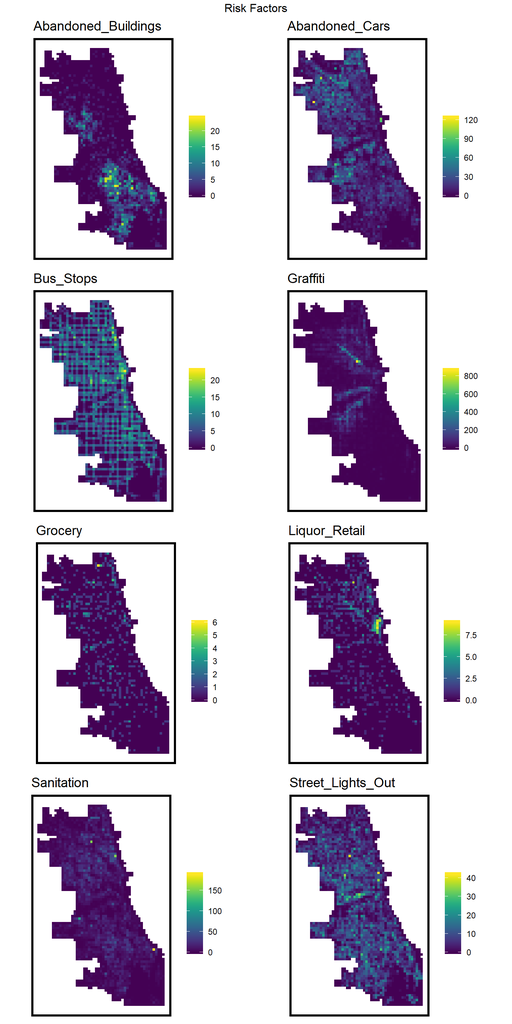

```r
#Load risk factors
#Abanonded Cars (311)
abandonCars <-
  read.socrata("https://data.cityofchicago.org/Service-Requests/311-Service-Requests-Abandoned-Vehicles/3c9v-pnva") %>%
  mutate(year = substr(creation_date,1,4)) %>%
  filter(year == "2017") %>%
  dplyr::select(Y = latitude, X = longitude) %>%
  na.omit() %>%
  st_as_sf(coords = c("X", "Y"), crs = 4326, agr = "constant") %>%
  st_transform(st_crs(fishnet)) %>%
  mutate(Legend = "Abandoned_Cars")

#Abandoned Buildings (311)
abandonBuildings <-
  read.socrata("https://data.cityofchicago.org/Service-Requests/311-Service-Requests-Vacant-and-Abandoned-Building/7nii-7srd") %>%
  mutate(year = substr(date_service_request_was_received,1,4)) %>%
  filter(year == "2017") %>%
  dplyr::select(Y = latitude, X = longitude) %>%
  na.omit() %>%
  st_as_sf(coords = c("X", "Y"), crs = 4326, agr = "constant") %>%
  st_transform(st_crs(fishnet)) %>%
  mutate(Legend = "Abandoned_Buildings")

#Graffiti Reports (311)
graffiti <-
  read.socrata("https://data.cityofchicago.org/Service-Requests/311-Service-Requests-Graffiti-Removal-Historical/hec5-y4x5") %>%
  mutate(year = substr(creation_date,1,4)) %>%
  filter(year == "2017") %>%
  filter(where_is_the_graffiti_located_ == "Front" |
           where_is_the_graffiti_located_ == "Rear" | where_is_the_graffiti_located_ == "Side") %>%
  dplyr::select(Y = latitude, X = longitude) %>%
  na.omit() %>%
  st_as_sf(coords = c("X", "Y"), crs = 4326, agr = "constant") %>%
  st_transform(st_crs(fishnet)) %>%
  mutate(Legend = "Graffiti")

#Street Lights Out (311)
streetLightsOut <-
  read.socrata("https://data.cityofchicago.org/Service-Requests/311-Service-Requests-Street-Lights-All-Out/zuxi-7xem") %>%
  mutate(year = substr(creation_date,1,4)) %>%
  filter(year == "2017") %>%
  dplyr::select(Y = latitude, X = longitude) %>%
  na.omit() %>%
  st_as_sf(coords = c("X", "Y"), crs = 4326, agr = "constant") %>%
  st_transform(st_crs(fishnet)) %>%
  mutate(Legend = "Street_Lights_Out")

#Sanitation Code Complaints (311)
sanitation <-
  read.socrata("https://data.cityofchicago.org/Service-Requests/311-Service-Requests-Sanitation-Code-Complaints-Hi/me59-5fac") %>%
  mutate(year = substr(creation_date,1,4)) %>%
  filter(year == "2017") %>%
  dplyr::select(Y = latitude, X = longitude) %>%
  na.omit() %>%
  st_as_sf(coords = c("X", "Y"), crs = 4326, agr = "constant") %>%
  st_transform(st_crs(fishnet)) %>%
  mutate(Legend = "Sanitation")

#Liquor Licenses (City of Chicago CED)
liquorRetail <-
  read.socrata("https://data.cityofchicago.org/Community-Economic-Development/Business-Licenses-Current-Liquor-and-Public-Places/nrmj-3kcf") %>%
  filter(BUSINESS.ACTIVITY == "Retail Sales of Packaged Liquor") %>%
  dplyr::select(Y = LATITUDE, X = LONGITUDE) %>%
  na.omit() %>%
  st_as_sf(coords = c("X", "Y"), crs = 4326, agr = "constant") %>%
  st_transform(st_crs(fishnet)) %>%
  mutate(Legend = "Liquor_Retail")

#Bus Stops (CTA)
busstops <-
  read.socrata("https://data.cityofchicago.org/resource/qs84-j7wh.json") %>%
  dplyr::select(Y = point_y, X = point_x) %>%
  na.omit() %>%
  st_as_sf(coords = c("X", "Y"), crs = 4326, agr = "constant") %>%
  st_transform(st_crs(fishnet)) %>%
  mutate(Legend = "Bus_Stops") %>%
  subset(select = c(geometry, Legend))

#Grocery Stores (City of Chicago CED)
grocery <-
  read.socrata("https://data.cityofchicago.org/Community-Economic-Development/Map-of-Grocery-Stores-2013/ce29-twzt") %>%
  dplyr::select(Y = LATITUDE, X = LONGITUDE) %>%
  na.omit() %>%
  st_as_sf(coords = c("X", "Y"), crs = 4326, agr = "constant") %>%
  st_transform(st_crs(fishnet)) %>%
  mutate(Legend = "Grocery") %>%
  subset(select = c(geometry, Legend))

#Neighborhoods
neighborhoods <-
  st_read("https://raw.githubusercontent.com/blackmad/neighborhoods/master/chicago.geojson") %>%
  st_transform(st_crs(fishnet))

#Plot all risk factors
vars_net <-
  rbind(abandonCars,streetLightsOut,abandonBuildings,
        liquorRetail, graffiti, sanitation, busstops, grocery) %>%
  st_join(., fishnet, join=st_within) %>%
  st_set_geometry(NULL) %>%
  group_by(uniqueID, Legend) %>%
  summarize(count = n()) %>%
  full_join(fishnet) %>%
  spread(Legend, count, fill=0) %>%
  st_sf() %>%
  dplyr::select(-`<NA>`) %>%
  na.omit()
#Plot each risk factor on a fishnet grid
vars_net.long <-
  vars_net %>%
  gather(Variable, value, -geometry, -uniqueID)

vars <- unique(vars_net.long$Variable)
mapList <- list()

for(i in vars){
  mapList[[i]] <-
    ggplot() +
    geom_sf(data = filter(vars_net.long, Variable == i), aes(fill=value), colour=NA) +
    scale_fill_viridis(name="") +
    labs(title=i) +
    mapTheme()}

do.call(grid.arrange,c(mapList, ncol =2, top = "Risk Factors"))
```

Some of these variables are similarly concentrated. Others are not as concentrated from a city-wide perspective. There are other types of analysis that can more accurately compare these variables to gun violence incidents. (3)

## Looking for correlations

When the predictive factors are plotted, both the factors and the observations are compared to determine if the predictive factors can predict in the hotspots (where there are many data points to test) and the cold spots (where there are fewer data points to test).

```r
#Create a function to calcualte the distance to the nearest neighbor
nn_function <- function(measureFrom,measureTo,k) {
  measureFrom_Matrix <-
    as.matrix(measureFrom)
  measureTo_Matrix <-
    as.matrix(measureTo)
  nn <-
    get.knnx(measureTo, measureFrom, k)$nn.dist
  output <-
    as.data.frame(nn) %>%
    rownames_to_column(var = "thisPoint") %>%
    gather(points, point_distance, V1:ncol(.)) %>%
    arrange(as.numeric(thisPoint)) %>%
    group_by(thisPoint) %>%
    summarize(pointDistance = mean(point_distance)) %>%
    arrange(as.numeric(thisPoint)) %>%
    dplyr::select(-thisPoint) %>%
    pull()

  return(output)
}

#Apply the function to the risk factors
vars_net$Abandoned_Buildings.nn =
  nn_function(st_coordinates(st_centroid(vars_net)), st_coordinates(abandonBuildings), 3)

vars_net$Abandoned_Cars.nn =
  nn_function(st_coordinates(st_centroid(vars_net)), st_coordinates(abandonCars), 3)

vars_net$Graffiti.nn =
  nn_function(st_coordinates(st_centroid(vars_net)), st_coordinates(graffiti), 3)

vars_net$Liquor_Retail.nn =
  nn_function(st_coordinates(st_centroid(vars_net)), st_coordinates(liquorRetail), 3)

vars_net$Street_Lights_Out.nn =
  nn_function(st_coordinates(st_centroid(vars_net)), st_coordinates(streetLightsOut), 3)

vars_net$Sanitation.nn =
  nn_function(st_coordinates(st_centroid(vars_net)), st_coordinates(sanitation), 3)

vars_net$grocery.nn =
  nn_function(st_coordinates(st_centroid(vars_net)), st_coordinates(grocery), 3)

vars_net$busstops.nn =
  nn_function(st_coordinates(st_centroid(vars_net)), st_coordinates(busstops), 3)

vars_net.long.nn <-
  vars_net %>%
  dplyr::select(ends_with(".nn")) %>%
  gather(Variable, value, -geometry, -uniqueID)
```

```r
vars <- unique(vars_net.long.nn$Variable)
mapList <- list()

for(i in vars){
  mapList[[i]] <-
    ggplot() +
    geom_sf(data = filter(vars_net.long.nn, Variable == i), aes(fill=value), colour=NA) +
    scale_fill_viridis(name="") +
    labs(title=i) +
    mapTheme()}

loopPoint <-
  neighborhoods %>%
  filter(name == "Loop") %>%
  st_centroid()

vars_net$loopDistance =
  st_distance(st_centroid(vars_net),loopPoint) %>%
  as.numeric()

final_net <-
  left_join(crime_net, st_set_geometry(vars_net, NULL), by="uniqueID")

final_net <-
  st_centroid(final_net) %>%
  st_join(., dplyr::select(neighborhoods, name)) %>%
  st_join(., dplyr::select(policeDistricts, District)) %>%
  st_set_geometry(NULL) %>%
  left_join(dplyr::select(final_net, geometry, uniqueID)) %>%
  st_sf() %>%
  na.omit()
final_net.nb <- poly2nb(final_net, queen=TRUE)
final_net.weights <- nb2listw(final_net.nb, style="W", zero.policy=TRUE)
```

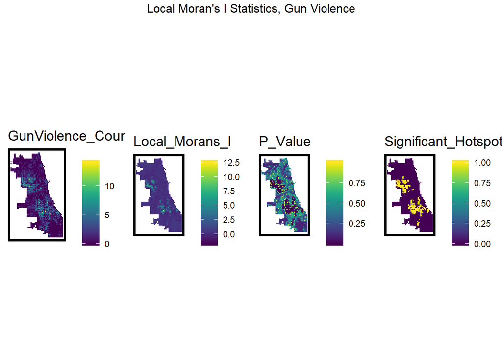

```r
#Calculate the Local Moran's I for each cell
final_net.localMorans <-
  cbind(
    as.data.frame(localmoran(final_net$countgunviolence, final_net.weights)),
    as.data.frame(final_net, NULL)) %>%
  st_sf() %>%
  dplyr::select(GunViolence_Count = countgunviolence,
                Local_Morans_I = Ii,
                P_Value = `Pr(z > 0)`) %>%
  mutate(Significant_Hotspots = ifelse(P_Value <= 0.05, 1, 0)) %>%
  gather(Variable, Value, -geometry)

vars <- unique(final_net.localMorans$Variable)
varList <- list()

for(i in vars){
  varList[[i]] <-
    ggplot() +
    geom_sf(data = filter(final_net.localMorans, Variable == i), aes(fill = Value), colour=NA) +
    scale_fill_viridis(name="") +
    labs(title=i) +
    mapTheme()}

#Plot Local Moran's I Statistics
do.call(grid.arrange,c(varList, ncol = 4, top = "Local Moran's I Statistics, Gun Violence"))
```

High “I” values in the second figure show that the data is correlated and the variables can be used to identify these clusters. (4)

## Testing the correlations

```r
#Identify correlations
final_net <-
  final_net %>%
  mutate(gunviolence.isSig = ifelse(localmoran(final_net$countgunviolence,
                                               final_net.weights)[,5] <= 0.0000001, 1, 0)) %>%
  mutate(gunviolence.isSig.dist = nn_function(st_coordinates(st_centroid(final_net)),
                                              st_coordinates(st_centroid(
                                                filter(final_net, gunviolence.isSig == 1))), 1 ))

correlation.long <-
  st_set_geometry(final_net, NULL) %>%
  dplyr::select(-uniqueID, -cvID, -loopDistance, -name, -District) %>%
  gather(Variable, Value, -countgunviolence)

correlation.cor <-
  correlation.long %>%
  group_by(Variable) %>%
  summarize(correlation = cor(Value, countgunviolence, use = "complete.obs"))
```

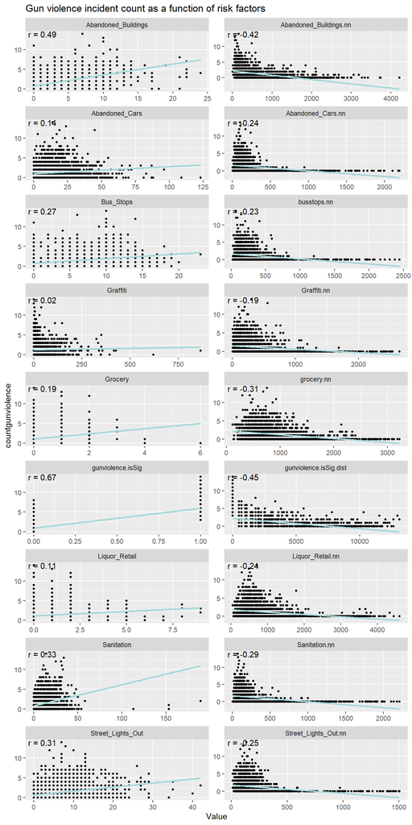

```r
#Plot correlations between risk factors and gun violence incidents
ggplot(correlation.long, aes(Value, countgunviolence)) +
  geom_point(size = 1) +
  geom_text(data = correlation.cor, aes(label = paste("r =", round(correlation, 2))),
            x=-Inf, y=Inf, vjust = 1, hjust = -.1) +
  geom_smooth(method = "lm", se = FALSE, colour = "#a2d7d8") +
  facet_wrap(~Variable, ncol = 2, scales = "free") +
  labs(title = "Gun violence incident count as a function of risk factors")
```

Discrete values and nearest neighbor values (indicated by .nn) are presented. The strongest correlations are Abandoned Buildings, Sanitation Code Violations, Street Lights reported out, and Presence of Grocery Stores (using Nearest Neighbor). For some risk factors, using the nearest neighbor increases the correlation, as in the case of graffiti reports. (5)

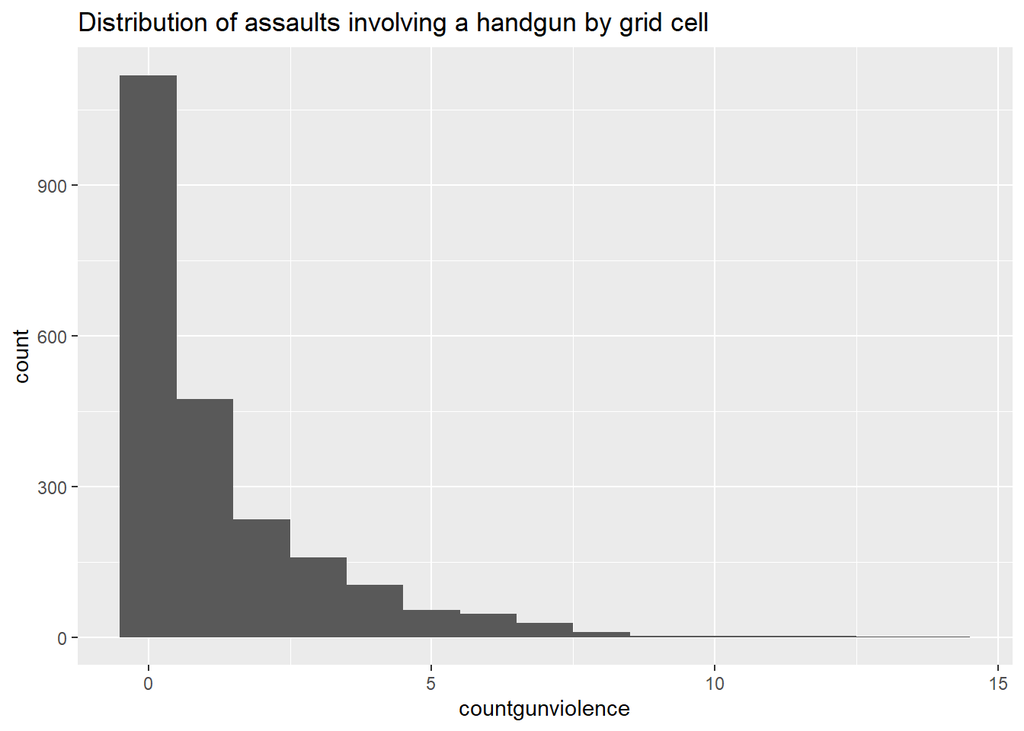

```r
ggplot(final_net, aes(countgunviolence)) +
  geom_histogram(binwidth = 1) +
  labs(title = "Distribution of assaults involving a handgun by grid cell")
```

Almost all cells have somewhere between 0-5 incidents. There are only a few hotspots where there are more than 5 instances. (6)

## Examining the predictions

```r
#Build the regressions, one with random k-folds and the other with spatial factors
reg.vars <- c("Abandoned_Buildings.nn", "Abandoned_Cars.nn", "Graffiti.nn",
              "Liquor_Retail.nn", "Street_Lights_Out.nn", "Sanitation.nn", "busstops.nn", "grocery.nn" , "loopDistance")

reg.ss.vars <- c("Abandoned_Buildings.nn", "Abandoned_Cars.nn", "Graffiti.nn", "Liquor_Retail.nn",
                 "Street_Lights_Out.nn", "Sanitation.nn", "busstops.nn", "grocery.nn" , "loopDistance",
                 "gunviolence.isSig", "gunviolence.isSig.dist")

#Cross-Validate the models
crossValidate <- function(dataset, id, dependentVariable, indVariables) {

  allPredictions <- data.frame()
  cvID_list <- unique(dataset[[id]])

  for (i in cvID_list) {

    thisFold <- i
    cat("This hold out fold is", thisFold, "\n")

    fold.train <- filter(dataset, dataset[[id]] != thisFold) %>% as.data.frame() %>%
      dplyr::select(id, geometry, indVariables, dependentVariable)
    fold.test  <- filter(dataset, dataset[[id]] == thisFold) %>% as.data.frame() %>%
      dplyr::select(id, geometry, indVariables, dependentVariable)

    regression <-
      glm(countgunviolence ~ ., family = "poisson",
          data = fold.train %>%
            dplyr::select(-geometry, -id))

    thisPrediction <-
      mutate(fold.test, Prediction = predict(regression, fold.test, type = "response"))

    allPredictions <-
      rbind(allPredictions, thisPrediction)

  }
  return(st_sf(allPredictions))
}
reg.cv <- crossValidate(
  dataset = final_net,
  id = "cvID",
  dependentVariable = "countgunviolence",
  indVariables = reg.vars) %>%
  dplyr::select(cvID = cvID, countgunviolence, Prediction, geometry)

reg.ss.cv <- crossValidate(
  dataset = final_net,
  id = "cvID",
  dependentVariable = "countgunviolence",
  indVariables = reg.ss.vars) %>%
  dplyr::select(cvID = cvID, countgunviolence, Prediction, geometry)

reg.spatialCV <- crossValidate(
  dataset = final_net,
  id = "name",
  dependentVariable = "countgunviolence",
  indVariables = reg.vars) %>%
  dplyr::select(cvID = name, countgunviolence, Prediction, geometry)

reg.ss.spatialCV <- crossValidate(
  dataset = final_net,
  id = "name",
  dependentVariable = "countgunviolence",
  indVariables = reg.ss.vars) %>%
  dplyr::select(cvID = name, countgunviolence, Prediction, geometry)

reg.summary <-
  rbind(
    mutate(reg.cv,           Error = countgunviolence - Prediction,
           Regression = "Random k-fold CV: Just Risk Factors"),

    mutate(reg.ss.cv,        Error = countgunviolence - Prediction,
           Regression = "Random k-fold CV: Spatial Structure"),

    mutate(reg.spatialCV,    Error = countgunviolence - Prediction,
           Regression = "Spatial LOGO-CV: Just Risk Factors"),

    mutate(reg.ss.spatialCV, Error = countgunviolence - Prediction,
           Regression = "Spatial LOGO-CV: Spatial Structure")) %>%
  st_sf()
```

The models based on the spatial structure are able to identify clusters of hotspots more precisely than those models that only rely on the predictive factors without being aware of their location (and therefore characteristic of clustering). (7)

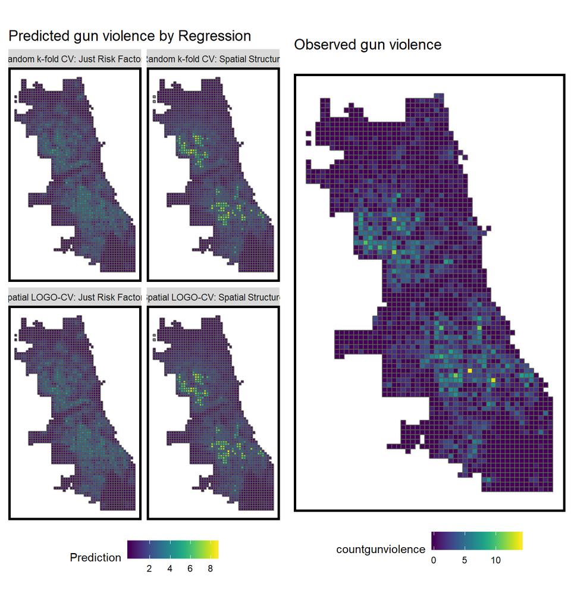

```r
#Plot the results of the regressions and compare to the observations
grid.arrange(
  reg.summary %>%
    ggplot() +
    geom_sf(aes(fill = Prediction)) +
    facet_wrap(~Regression) +
    scale_fill_viridis() +
    labs(title = "Predicted gun violence by Regression") +
    mapTheme() + theme(legend.position="bottom"),

  filter(reg.summary, Regression == "Random k-fold CV: Just Risk Factors") %>%
    ggplot() +
    geom_sf(aes(fill = countgunviolence)) +
    scale_fill_viridis() +
    labs(title = "Observed gun violence\n") +
    mapTheme() + theme(legend.position="bottom"), ncol = 2)
```

Notice that the error terms are smaller for the model that includes the spatial structure. (8)

```r
#Examine MAE and Standard Deviation MAE
st_set_geometry(reg.summary, NULL) %>%
  group_by(Regression) %>%
  summarize(MAE = round(mean(abs(Prediction - countgunviolence), na.rm = T),2),
            SD_MAE = round(sd(abs(Prediction - countgunviolence), na.rm = T),2)) %>%
  kable(caption = "MAE by regression") %>%
  kable_styling("striped", full_width = F) %>%
  row_spec(2, color = "black", background = "#FDE725FF") %>%
  row_spec(4, color = "black", background = "#FDE725FF")
```

MAE by regression

| Regression | MAE | SD_MAE |
| --- | --- | --- |
| Random k-fold CV: Just Risk Factors | 0.97 | 1.09 |
| Random k-fold CV: Spatial Structure | 0.82 | 0.85 |
| Spatial LOGO-CV: Just Risk Factors | 0.97 | 1.10 |
| Spatial LOGO-CV: Spatial Structure | 0.82 | 0.85 |

## Examining the model for racial bias

Census data is useful in determining if there is an inherent bias in the model. A good model is able to predict these incidents in neighborhoods taht are majority white and non-white.

```r
#Bring in Census Data
tracts17 <-
  get_acs(geography = "tract", variables = c("B01001_001E","B01001A_001E"),
          year = 2017, state=17, county=031, geometry=T, key ='053d2e734ebc2fbd179ef726354582db8fc28748') %>%
  st_transform(102271)  %>%
  dplyr::select(variable, estimate, GEOID) %>%
  spread(variable, estimate) %>%
  rename(TotalPop = B01001_001,
         NumberWhites = B01001A_001) %>%
  mutate(percentWhite = NumberWhites / TotalPop,
         raceContext = ifelse(percentWhite > .5, "Majority_White", "Majority_Non_White")) %>%
  .[neighborhoods,]
#Compare the regressions to determine if there is a racial bias
final_reg <-
  filter(reg.summary, Regression == "Spatial LOGO-CV: Spatial Structure" |
           Regression == "Spatial LOGO-CV: Just Risk Factors") %>%
  mutate(uniqueID = rownames(.))

final_reg.tracts <-
  st_join(st_centroid(final_reg), tracts17) %>%
  st_set_geometry(NULL) %>%
  left_join(dplyr::select(final_reg, uniqueID)) %>%
  st_sf() %>%
  na.omit()

st_set_geometry(final_reg.tracts, NULL) %>%
  group_by(Regression, raceContext) %>%
  summarize(mean.Error = mean(Error, na.rm = T)) %>%
  spread(raceContext, mean.Error) %>%
  kable(caption = "Mean Error by neighborhood with racial context (9)") %>%
  kable_styling("striped", full_width = F)
```

Mean Error by neighborhood with racial context (9)

| Regression | Majority_Non_White | Majority_White |
| --- | --- | --- |
| Spatial LOGO-CV: Just Risk Factors | 0.2571782 | -0.2669126 |
| Spatial LOGO-CV: Spatial Structure | 0.1140811 | -0.1175939 |

## Evaluating the model

A simple comparison of reported assaults involving a handgun against the areas of Chicago where the model predicts these crimes to occur can determine how well the model does at identifying hotspots relative to where they have actually been observed. Both the observations and the predictions are categorized by an index. Areas where the risk of such an assault is highest are denoted by a risk of 90% or greater. (10)

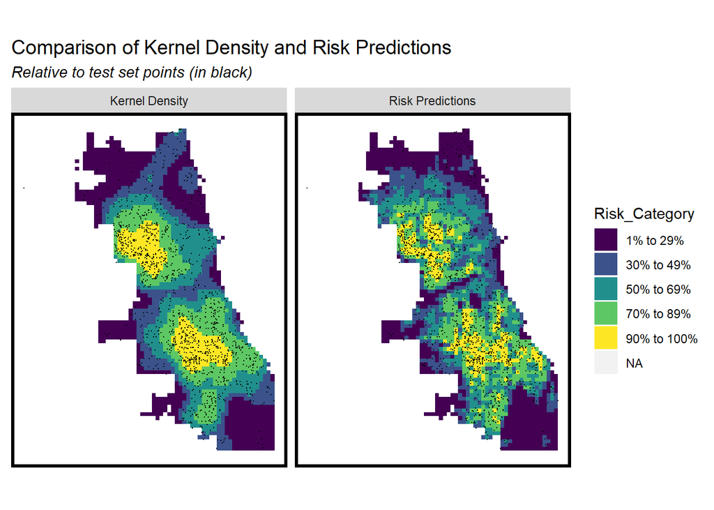

```r
#Categorize each cell by the density of incidents, per the model and observations.
library(raster)
gv_ppp <- as.ppp(st_coordinates(gunviolence), W = st_bbox(final_net))
gv_KD.1000 <- spatstat::density.ppp(gv_ppp, 1000)
gv_KD.1500 <- spatstat::density.ppp(gv_ppp, 1500)
gv_KD.2000 <- spatstat::density.ppp(gv_ppp, 2000)
gv_KD.df <- rbind(
  mutate(data.frame(rasterToPoints(mask(raster(gv_KD.1000), as(neighborhoods, 'Spatial')))), Legend = "1000 Ft."),
  mutate(data.frame(rasterToPoints(mask(raster(gv_KD.1500), as(neighborhoods, 'Spatial')))), Legend = "1500 Ft."),
  mutate(data.frame(rasterToPoints(mask(raster(gv_KD.2000), as(neighborhoods, 'Spatial')))), Legend = "2000 Ft."))

gv_KD.df$Legend <- factor(gv_KD.df$Legend, levels = c("1000 Ft.", "1500 Ft.", "2000 Ft."))

gv_ppp <- as.ppp(st_coordinates(gunviolence), W = st_bbox(final_net))
gv_KD <- spatstat::density.ppp(gv_ppp, 1000)

# Compute kernel density
gv_ppp <- as.ppp(st_coordinates(gunviolence), W = st_bbox(final_net))
gv_KD <- spatstat::density.ppp(gv_ppp, 1000)
# Convert kernel density to grid cells taking the mean
gv_KDE_sf <- as.data.frame(gv_KD) %>%
  st_as_sf(coords = c("x", "y"), crs = st_crs(final_net)) %>%
  aggregate(., final_net, mean) %>%
  #Mutate the Risk_Category field as defined below.
  mutate(label = "Kernel Density",
         Risk_Category = ntile(value, 100),
         Risk_Category = case_when(
           Risk_Category >= 90 ~ "90% to 100%",
           Risk_Category >= 70 & Risk_Category <= 89 ~ "70% to 89%",
           Risk_Category >= 50 & Risk_Category <= 69 ~ "50% to 69%",
           Risk_Category >= 30 & Risk_Category <= 49 ~ "30% to 49%",
           Risk_Category >= 1 & Risk_Category <= 29 ~ "1% to 29%")) %>%
  #Bind to a layer where test set crime counts are spatially joined to the fisnnet.
  bind_cols(
    aggregate(
      dplyr::select(gunviolence) %>% mutate(gvCount = 1), ., length) %>%
      mutate(gvCount = replace_na(gvCount, 0))) %>%
  #Select the fields we need
  dplyr::select(label, Risk_Category, gvCount)

gv_risk_sf <-
  filter(final_reg, Regression == "Spatial LOGO-CV: Spatial Structure") %>%
  mutate(label = "Risk Predictions",
         Risk_Category = ntile(Prediction, 100),
         Risk_Category = case_when(
           Risk_Category >= 90 ~ "90% to 100%",
           Risk_Category >= 70 & Risk_Category <= 89 ~ "70% to 89%",
           Risk_Category >= 50 & Risk_Category <= 69 ~ "50% to 69%",
           Risk_Category >= 30 & Risk_Category <= 49 ~ "30% to 49%",
           Risk_Category >= 1 & Risk_Category <= 29 ~ "1% to 29%")) %>%
  bind_cols(
    aggregate(
      dplyr::select(gunviolence) %>% mutate(gvCount = 1), ., length) %>%
      mutate(gvcount = replace_na(gvCount, 0))) %>%
  dplyr::select(label,Risk_Category, gvCount)

#Plot the incident desnity vs risk predictions
rbind(gv_KDE_sf, gv_risk_sf) %>%
  gather(Variable, Value, -label, -Risk_Category, -geometry) %>%
  ggplot() +
  geom_sf(aes(fill = Risk_Category), colour = NA) +
  geom_sf(data = sample_n(gunviolence, 1500), size = .1, colour = "black") +
  facet_wrap(~label, ) +
  scale_fill_viridis(discrete = TRUE) +
  labs(title="Comparison of Kernel Density and Risk Predictions",
       subtitle="Relative to test set points (in black)") +
  mapTheme()
```

This graph shows that the model does well at predicting risk when the risk is under 70% but can either under or over predict when the risk is greater than 70%. This figure is helpful to those tuning the model to understand that the model is lacking one or more features that may more accureatley describe an factor unaccounted for in the model, that does a better job of predicitng these crimes in the areas where they are the most prevelant. (11)

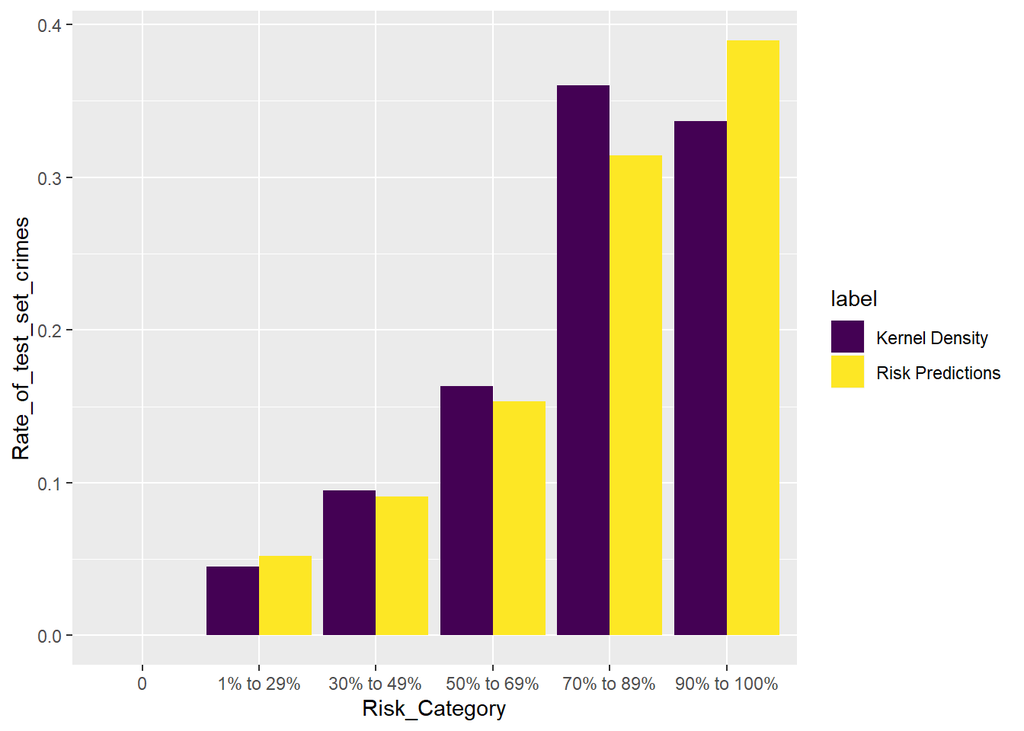

```r
#Compare observations and predictions to determine how the model performs at each risk level.
gv_risk_sf[is.na(gv_risk_sf)] <- 0
rbind(gv_KDE_sf, gv_risk_sf) %>%
  st_set_geometry(NULL) %>%
  gather(Variable, Value, -label, -Risk_Category) %>%
  group_by(label, Risk_Category) %>%
  summarize(countgunviolence = sum(Value)) %>%
  ungroup() %>%
  group_by(label) %>%
  mutate(Rate_of_test_set_crimes = countgunviolence / sum(countgunviolence)) %>%
  ggplot(aes(Risk_Category,Rate_of_test_set_crimes)) +
  geom_bar(aes(fill=label), position="dodge", stat="identity") +
  scale_fill_viridis(discrete = TRUE)
```

## Models in Practice

This algorithm relies on the premise that crimes are clustered and not universally distributed. Going off this assumption, the model determines that other risk factors that are also clustered in the same areas must be predictors of this anomaly. These algorithms are generally considered reliable because they look for clusters of several variables when identifying correlations. However, selection bias can skew the observed anomalies as many more instances are likely occurring, but not being reported. This model should only be used for crimes in which the confidence in the reporting rate is high. Additionally, the model relies on data of which incidents have already happened. Existing efforts by government and law enforcement may already be preventing this type of gun violence in places where the environment would suggest it would likely to occur. If the community reallocates resources away from areas where the model is less confident in its risk assessment, the presence of these crimes could increase.

The most promising application of this model would be for community agencies and local governments to determine where to intervene. Those areas with the greatest risk should be paid special attention to. Using predictive factors allows these stakeholders to determine what is influencing this type of crime. When the model predicts risk in areas where certain risk factors are high, the community would be smart to start by reducing the risk factors and determining if this in turn, reduces the crime risk. The model suggests that such action would in fact reduce the crime incidents. The model could be adapted to understand crime frequency. Once a community experiences the first experience with a crime, how likely is it that the same crime will be repeated during a certain period of time. This would allow community organizations to switch to preventive intervention to determine which communities are at the highest risk of perpetual crime. Keeping these models open source could prove a new valuable tool for community organizations to understand crime and how crime can be predicted and prevented.